# 49 [부록 2] 선별 아이템의 유형화

## 49.1 선별 아이템의 유형 분류 개요

- 라이덴 클러스터 4215개에 대해 6개 유형, 총 22개 지표를 적용하여 지표값을 합산한 **총점** 기준으로 상위 371개 아이템 선별하고 아래 두 가지 방식으로 유형화
  - (1) 유사도 기반 유형화: 클러스터 간 인용관계를 적용하여, 371개 아이템을 41개 **Meso**, 3개 **Macro** 로 재클러스터링 수행. 기술적 내용의 유사한 아이템 탐색을 지원
  - (2) 계량지표 기반 유형화: 6개 유형의 지표 점수를 기준으로 371개 아이템을 5개 유형으로 분류함. 계량적 특성이 비슷한 아이템들을 개념화하여 아이템 간의 직관적인 비교분석 지원

[figure not shown]

그림 49.1: 선별 아이템의 분류 과정 도식

## 49.2 지표 체계와 분포 특성

- 본 분석의 지표 값들은 표 49.1 에서 확인할 수 있듯이 대부분 비대칭 분포임. 극단치에 대한 강건성을 높이고 지표값의 변별력 제고, 지표 간 비교를 용이하기 위해 지표별로 5분위 기반 구간[^1]을 설정하였음.
  - 상위 1분위, 2분위, 3분위에 대해 이산적(discrete) 점수 체계 구성
  - 개별 클러스터 별로 만점 120점이 되도록 6개 유형별로 다이내믹스(45점), 융합성(15점), 영향력(10점), 산업연계(20점), 투자기반(10점), 한국수준(20점)과 같이 배분

<sup>1</sup> 특정한 값의 수준 자체가 특정한 의미를 갖는 일부 지표에서는 5분위 구간 방식을 적용하지 않음. 이에 대한 설명은 각각 딥러닝 기반 지표 점수 부여, 한국 엑셀런스 링크 참조.

- 표 49.2 는 선별된 371개 아이템에서 지표값들의 분포를 나타냄.
- 전체 클러스터에 비해 지표값들의 비대칭성 또는 왜도가 낮아짐을 확인할 수 있음.

표 49.1: 전체 클러스터(4215개)의 지표값 분포

계량지표

최소값

중앙값

최대값

표준편차

왜도

결측치 수

분포

다이내믹스 (45)

딥러닝(MLP) 기반 성장성 확률  
deep_mlp_prob

0

0

1

0.43

0.98

832

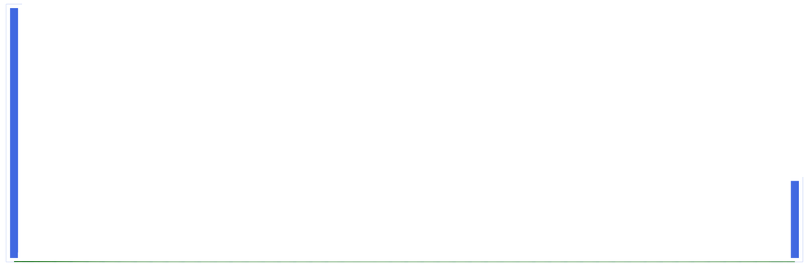

딥러닝(attention) 기반 성장성 확률  
deep_attention_prob

0

0.04

1

0.42

0.71

832

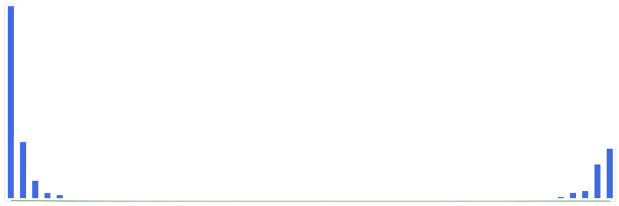

급부상성 점수(규모)  
emergence_score

-23.16

0.1

253.52

4.93

34.34

0

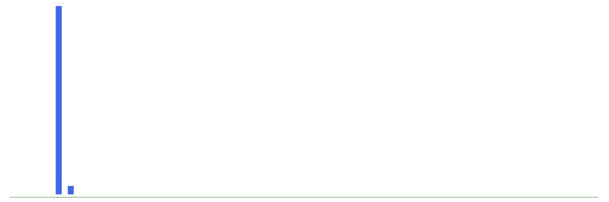

급부상성 점수(확산)  
emergence_diffu_score

-56.22

0.37

156.48

7.43

7.43

90

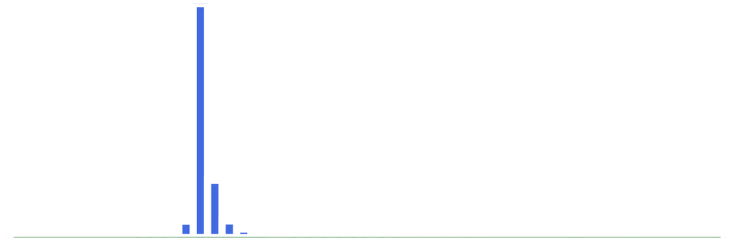

최신성(가중평균년도)  
avg_pubyear_06_21

2009.68

2014.36

2020.5

1.26

0.71

0

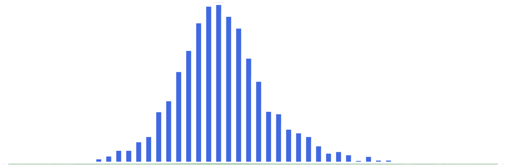

연평균복합성장률(규모)  
cagr_pub

-27.72

4.43

77.87

8.28

2.72

0

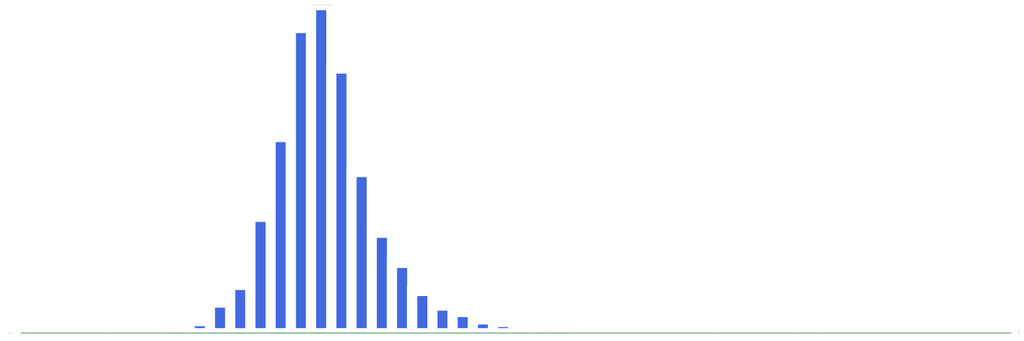

연평균복합성장률(확산)  
cagr_diffu

-6.9

19.93

101.47

9.76

2.48

0

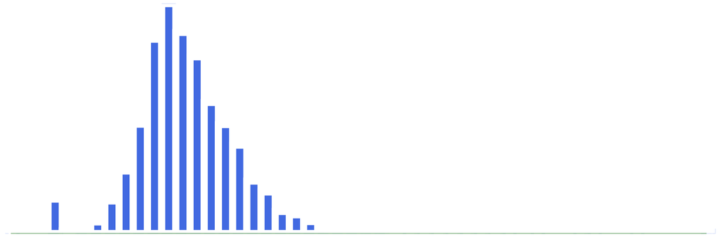

융합성 (15)

Rao-Stirling 다양성 지수(WoS분류)  
rs_div_wcate_17_21

0.03

0.53

0.82

0.12

-0.76

0

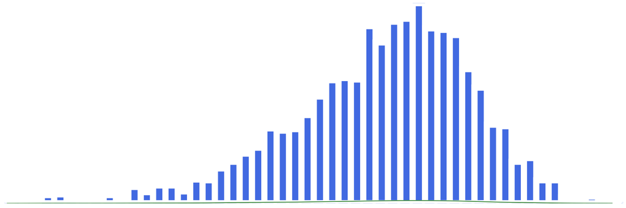

Rao-Stirling 다양성 지수(Citation Topics)  
rs_div_ct_17_21

0.03

0.58

0.95

0.18

-0.4

0

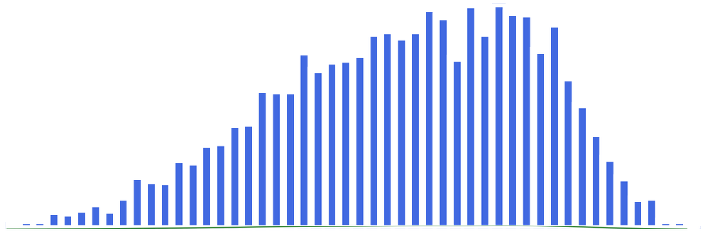

클러스터 지식흐름의 사이중앙성  
centrality_btwn

0

2905

510876

28794.98

8.05

0

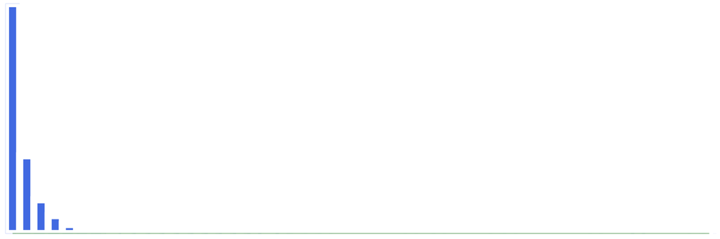

영향력 (10)

클러스터 단위 엑셀런스(2016-2018년)  
excellence_pp10_1618

0

6.06

66.77

6.58

2.42

0

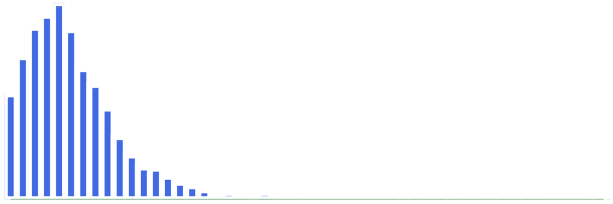

클러스터 단위 엑셀런스(2019-2021년)  
excellence_pp10_1921

0

5.44

58.59

5.83

2.34

0

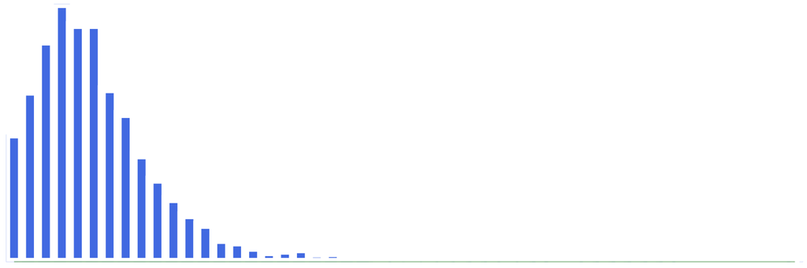

산업연계 (20)

산업활용성(2006-2021년)  
prop_cited_by_pat_06_21

0

5.67

47.01

7.3

1.08

0

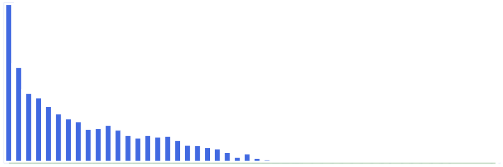

산업활용성(2017-2021년)  
prop_cited_by_pat_17_21

0

2.5

33.4

4.01

1.62

0

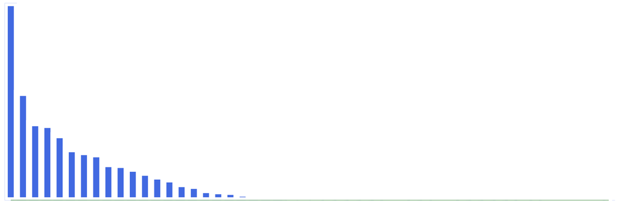

산업기반성(2006-2021년)  
prop_citting_pat_06_21

0

1.11

144.13

8.47

5.3

0

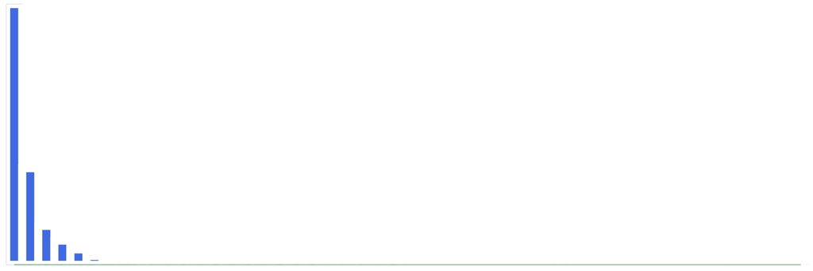

산업기반성(2017-2021년)  
prop_citting_pat_17_21

0

0.68

58.48

3.18

4.68

0

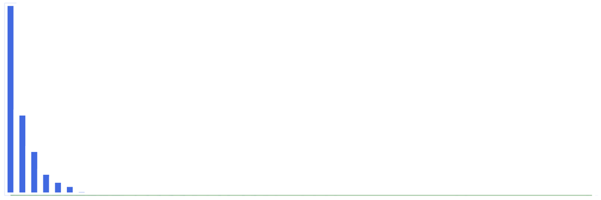

투자기반 (10)

한국 투자규모(2017-2021년)  
fund_total_bwon

0

14.88

1231.74

108.96

4.51

0

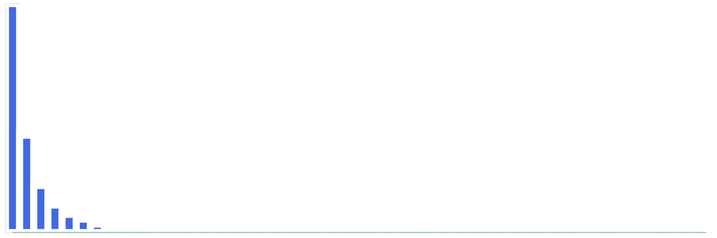

한국 투자 과제수(2017-2021년)  
n_projects

0

30

4489

219.24

9.07

0

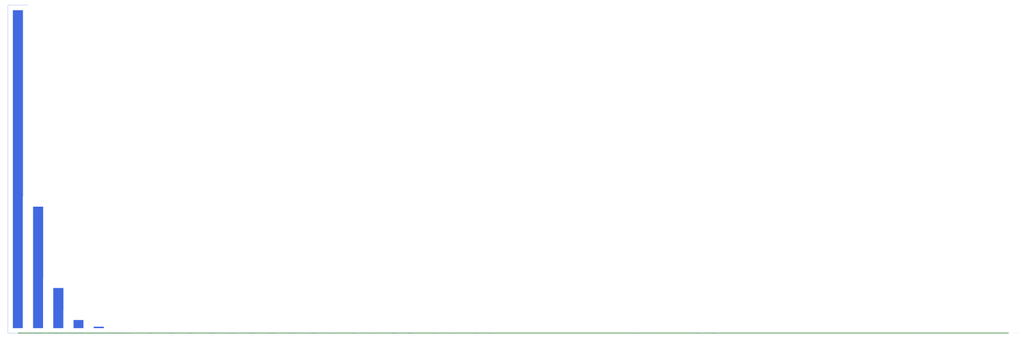

한국수준 (20)

한국 점유율(2006-2021년)  
kr_share_06_21

0

2.62

73.6

3.71

5.32

0

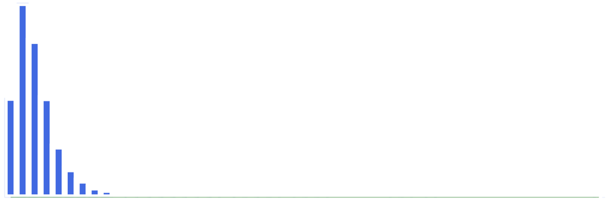

한국 점유율(2017-2021년)  
kr_share_17_21

0

2.69

63.53

3.6

5.47

0

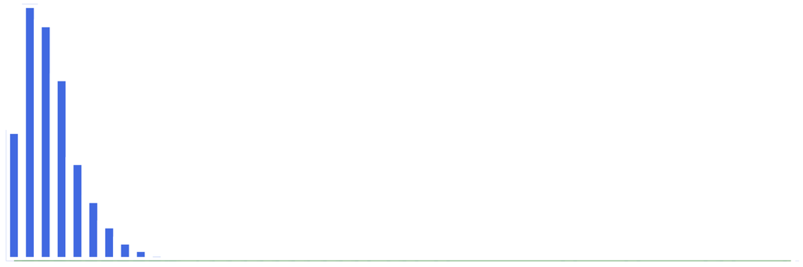

한국 엑셀런스(2016-2018년)  
kr_excel_pp10_1618

0

1.52

100

9.31

4.16

0

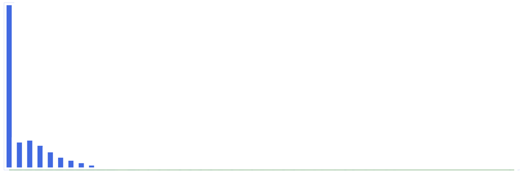

한국 엑셀런스(2019-2021년)  
kr_excel_pp10_1921

0

1.9

100

8.46

3.79

0

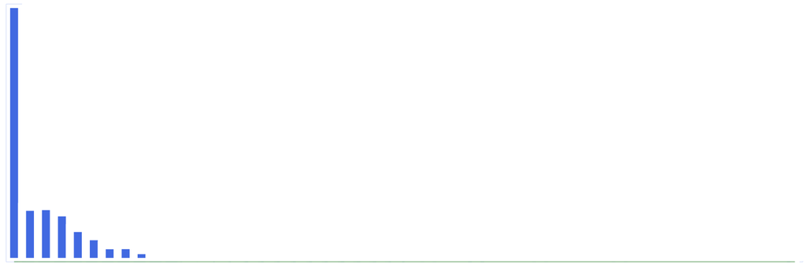

표 49.2: 선별 클러스터(371개)의 지표값 분포

계량지표

최소값

중앙값

최대값

표준편차

왜도

결측치 수

분포

다이내믹스 (45)

딥러닝(MLP) 기반 성장성 확률  
deep_mlp_prob

0

1

1

0.29

-2.58

0

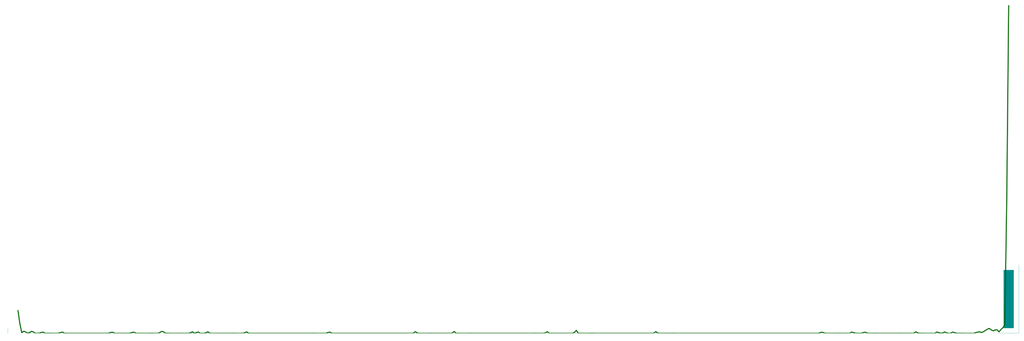

딥러닝(attention) 기반 성장성 확률  
deep_attention_prob

0

0.99

1

0.25

-2.51

0

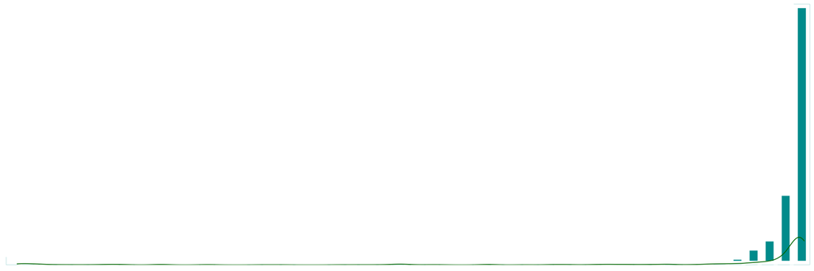

급부상성 점수(규모)  
emergence_score

-7.41

2.8

253.52

14.04

15.11

0

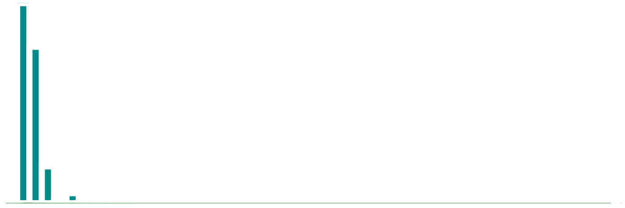

급부상성 점수(확산)  
emergence_diffu_score

-12.18

7.18

113.85

13.57

3.4

0

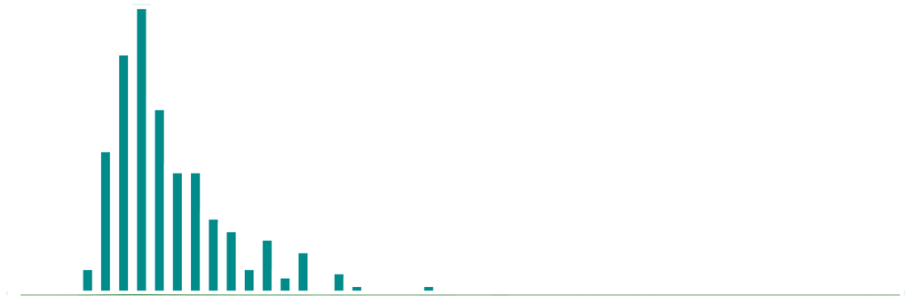

최신성(가중평균년도)  
avg_pubyear_06_21